# Caterpillar Abundance Analysis

Edward R. Ivimey-Cook

25 October 2026

## Introduction

This report examines how caterpillar abundance varies across habitat types, using a Poisson generalised linear model and a boxplot of counts by habitat. It produces the numeric results in the “Caterpillar Abundance” section of the manuscript and Figure 1.

### Packages

The analysis uses three packages: `dplyr` (summarising and filtering data), `ggplot2` (Figure 1) and `here` (relative file paths). They are loaded with `library()` at the start, so the packages needed are listed in one place and a missing package gives an error straight away. Functions from these packages are also called with their package name (for example `dplyr::filter()`), so it is clear where each one comes from. The R and package versions used are listed under Session information at the end of this report.

```r
## Load packages (R 4.1 or later is needed for the |> pipe)
library(dplyr)
library(ggplot2)
library(here)
```

## Data

### Import

Caterpillar counts and their associated habitat are read in from a CSV file, using `here::here()` so the path is relative to the project folder and does not rely on local file paths.

```r
## Load caterpillar abundance data (relative path, no local file paths)
data <- read.csv(here::here("caterpillar_data", "data.csv"))
```

### Removing erroneous records

Values from habitat D are removed, as these are known to be an error.

```r
## Remove values from habitat D as these are an error
filtered_data <- data |>
  dplyr::filter(habitat != "D")
```

### Descriptive summary

The mean number of caterpillars, with standard deviation, is summarised for each habitat, after habitat D has been removed.

```r
## Summarise the mean number of caterpillars, with standard deviation, by habitat
summary_data <- filtered_data |>
  dplyr::group_by(habitat) |>
  dplyr::summarise(
    mean_count = mean(caterpillar_count),
    sd = sd(caterpillar_count)
  )

summary_data
```

```
## # A tibble: 4 × 3
##   habitat mean_count    sd
##   <chr>        <dbl> <dbl>
## 1 A             5.67  2.31
## 2 B             8.77  2.90
## 3 C            14.6   2.70
## 4 E            25.3   6.01
```

## Statistical analysis

A Poisson generalised linear model is used to analyse caterpillar abundance by habitat.

```r
## Run a Poisson generalised linear model to analyse caterpillar abundance
## varying with habitat. Produces numeric results in "Caterpillar Abundance"
model1 <- glm(caterpillar_count ~ habitat,
              family = poisson, data = filtered_data)

summary(model1)
```

```
##
## Call:
## glm(formula = caterpillar_count ~ habitat, family = poisson,
##     data = filtered_data)
##
## Coefficients:
##             Estimate Std. Error z value Pr(>|z|)
## (Intercept)  1.73460    0.07670  22.616  < 2e-16 ***
## habitatB     0.43636    0.09841   4.434 9.25e-06 ***
## habitatC     0.94413    0.09039  10.445  < 2e-16 ***
## habitatE     1.49488    0.08486  17.615  < 2e-16 ***
## ---
## Signif. codes:  0 '***' 0.001 '**' 0.01 '*' 0.05 '.' 0.1 ' ' 1
##
## (Dispersion parameter for poisson family taken to be 1)
##
##     Null deviance: 592.00  on 119  degrees of freedom
## Residual deviance: 113.59  on 116  degrees of freedom
## AIC: 632.93
##
## Number of Fisher Scoring iterations: 4
```

Habitat significantly alters caterpillar abundance.

## Visualisation

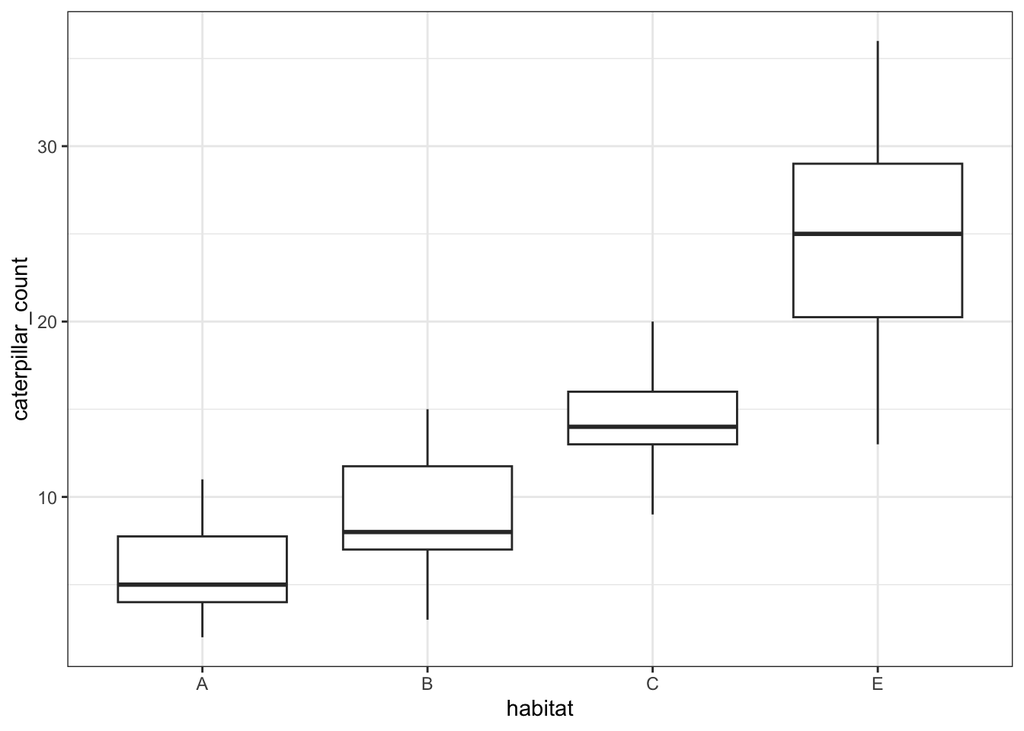

```r
## Create Figure 1, caterpillar count against habitat
figure1 <- ggplot2::ggplot(
  filtered_data,
  ggplot2::aes(x = habitat, y = caterpillar_count)
) +
  ggplot2::geom_boxplot() +
  ggplot2::theme_bw()

print(figure1)
```

Habitat E has the highest caterpillar count.

## Session information

The R version, operating system and package versions used to produce this report.

[session information not shown]